# Third week: Introduction to R and Rstudio

LaLiga Analysis

Aida Ramezani 95105595

2018-02-27 12:53:30

توجه شود که در تمامی سوالها، در صورت برابر بودن امتیاز دوتیم، رتبه تیمی برتر است که تفاضل مجموع گل های زده شده توسط آن تیم از مجموع گل های خورده، بیشینه باشد  
1)

[interactive chart not shown]

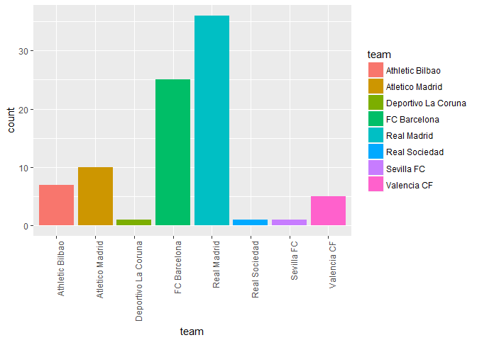

2. دو نمودار اول، کسل کننده ترین لیگ هارا بر اساس، میانگین گل های زده شده در لیگ، پیدا کرده و از دو روش نمودار آن ها را کشیده ام  
   دو نمودار دوم نیز، کسل کننده ترین تیم هارا بر اساس درصد بازی هایی که در آن های به نتیجه تساوی رسیده اند پیدا کرده و نمودار آن ها را با دو روش کشیده ام.

[interactive chart not shown]

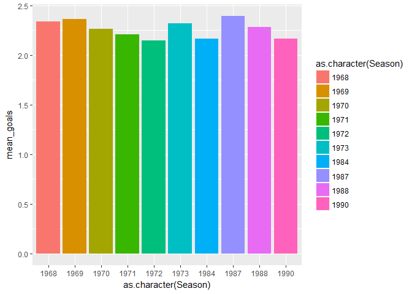

[interactive chart not shown]

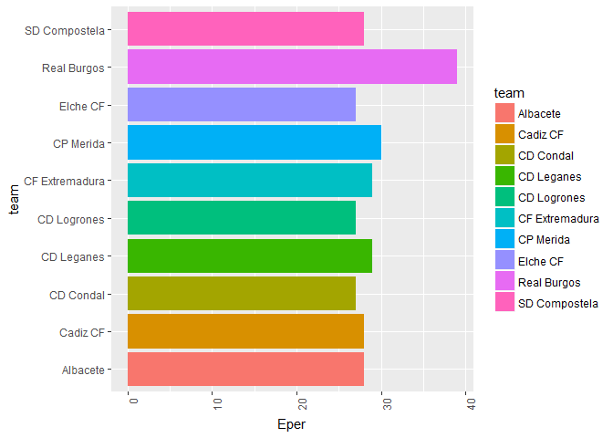

```
## [1] 60.47
```

4. در جدول زیر،تیم های برتر این 10 سال در سطر اول مشخص شده اند. سپس به ازای هر سال، گربه سیاه 4 تیم برتر آن سال، درخانه زیر آن ها نوشته شده است.خانه های خالی یعنی آن تیم در آن سال تیم برتر نبوده و در نتیجه گربه سیاه برای آن محاسبه کنشده است. گربه سیاه ها نیز تیم هایی هستند که در هر سال, جز 4 تیم برتر نبوده و با یک تیم برتر، دفعات زیادی را برده و یا مساوی کرده اند.

   | Season | Atletico Madrid | CA Osasuna | Celta Vigo | Deportivo La Coruna | FC Barcelona | Real Betis | Real Madrid | Real Sociedad | Sevilla FC | Valencia CF | Villarreal CF |
   | --- | --- | --- | --- | --- | --- | --- | --- | --- | --- | --- | --- |
   | 2001 |  |  |  | RCD Mallorca | CD Alaves |  | Real Sociedad |  |  | Real Sociedad |  |
   | 2002 |  |  | Villarreal CF | RCD Mallorca |  |  | RCD Mallorca | Athletic Bilbao |  |  |  |
   | 2003 |  |  |  | RCD Mallorca | Malaga CF |  | Real Sociedad |  |  | Albacete |  |
   | 2004 |  |  |  |  | Atletico Madrid | Espanyol Barcelona | Athletic Bilbao |  |  |  | Deportivo La Coruna |
   | 2005 |  | Getafe CF |  |  | Atletico Madrid |  | Deportivo La Coruna |  | Espanyol Barcelona | Getafe CF |  |
   | 2006 |  |  |  |  | Espanyol Barcelona |  | Recreativo Huelva |  | RCD Mallorca | Athletic Bilbao |  |
   | 2007 | Racing Santander |  |  |  | Getafe CF |  | UD Almeria |  | UD Almeria |  | Real Valladolid |
   | 2008 | Malaga CF |  |  |  | CA Osasuna |  | Valencia CF |  | Villarreal CF |  |  |
   | 2009 |  |  |  |  | Atletico Madrid |  | Athletic Bilbao |  | Getafe CF | Real Zaragoza |  |
   | 2010 |  |  |  |  | Hercules CF |  | CA Osasuna |  |  | null | null |

5. در خط اول مقتدرانه ترین پیروزی و سال رخداد آن را مشاهده میکنید.

```
## # A tibble: 1 x 2
## # Groups:   Season [1]
##   Season        team
##    <dbl>       <chr>
## 1   1962 Real Madrid
```

در جدول زیر، زودترین پیروزی و سال رخداد آن را مشاهده میکنید.

```
## # A tibble: 1 x 5
##          team Season gamesLeft point  rank
##         <chr>  <dbl>     <int> <dbl> <int>
## 1 Real Madrid   1974         5    68     1
```

به ترتیب طولانی ترین نوار های پیروزی، باخت و تساوی آورده شده اند.

```
## # A tibble: 1 x 3
##   Season         team consecutiveWins
##    <dbl>        <chr>           <dbl>
## 1   2012 FC Barcelona              25
```

```
## # A tibble: 3 x 3
##   Season             team consecutiveLoses
##    <dbl>            <chr>            <dbl>
## 1   1954 Racing Santander               16
## 2   1980       AD Almeria               16
## 3   1981         Cadiz CF               16
```

```
## # A tibble: 1 x 3
##   Season        team consecutiveEquals
##    <dbl>       <chr>             <dbl>
## 1   1984 Hercules CF                 8
```

7. در جدول زیر 4 ردیف داریم به این صورت که تیم اول در برابر تیم دوم و تیم سوم در برابر تیم چهارم دچار زود ترین سقوط شده اند.

```
## # A tibble: 4 x 4
##                 team Season gamesLeft point
##                <chr>  <dbl>     <int> <dbl>
## 1       CD Castellon   1981         8    12
## 2 Espanyol Barcelona   1981         8    37
## 3     Sporting Gijon   1997         8    10
## 4      Real Zaragoza   1997         8    38
```

[interactive chart not shown]

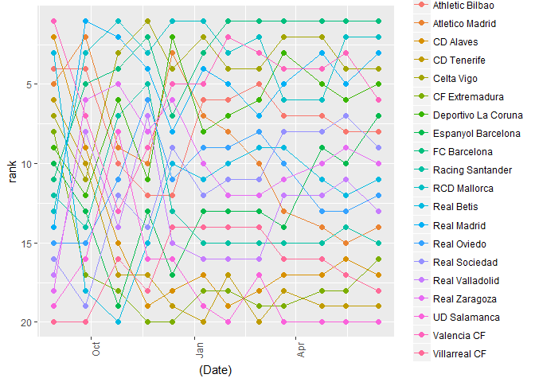

9. Using Kable:

   | teams | Celta Vigo | Sevilla FC | RCD Mallorca | Athletic Bilbao | Real Madrid | FC Barcelona | Levante UD | Deportivo La Coruna | Rayo Vallecano | Real Zaragoza | Real Sociedad | Real Betis | Espanyol Barcelona | Malaga CF | CA Osasuna | Getafe CF | Granada CF | Valencia CF | Real Valladolid | Atletico Madrid |
   | --- | --- | --- | --- | --- | --- | --- | --- | --- | --- | --- | --- | --- | --- | --- | --- | --- | --- | --- | --- | --- |
   | Celta Vigo | NA | 2-0 | 1-1 | 1-1 | 1-2 | 2-2 | 1-1 | 1-1 | 0-2 | 2-1 | 1-1 | 0-1 | 1-0 | 0-1 | 2-0 | 2-1 | 2-1 | 0-1 | 3-1 | 1-3 |
   | Sevilla FC | 0-2 | NA | 3-2 | 2-1 | 1-0 | 2-3 | 0-0 | 3-1 | 2-1 | 4-0 | 1-2 | 5-1 | 3-0 | 0-2 | 1-0 | 2-1 | 3-0 | 4-3 | 1-2 | 0-1 |
   | RCD Mallorca | 1-1 | 2-3 | NA | 0-1 | 0-5 | 2-4 | 1-1 | 2-3 | 1-1 | 1-1 | 1-0 | 1-0 | 2-1 | 2-3 | 1-1 | 1-3 | 1-2 | 2-0 | 4-2 | 1-1 |
   | Athletic Bilbao | 1-1 | 1-2 | 1-0 | NA | 0-3 | 2-2 | 0-1 | 1-1 | 1-2 | 0-2 | 1-3 | 3-5 | 0-4 | 0-0 | 1-0 | 1-2 | 1-0 | 1-0 | 2-0 | 3-0 |
   | Real Madrid | 2-1 | 0-1 | 5-0 | 3-0 | NA | 2-1 | 5-1 | 5-1 | 2-0 | 4-0 | 4-3 | 3-1 | 2-2 | 6-2 | 4-2 | 4-0 | 3-0 | 1-1 | 4-3 | 2-0 |
   | FC Barcelona | 2-2 | 3-2 | 4-2 | 2-2 | 1-2 | NA | 1-0 | 2-0 | 3-1 | 3-1 | 5-1 | 4-2 | 4-0 | 4-1 | 5-1 | 6-1 | 2-0 | 1-0 | 2-1 | 4-1 |
   | Levante UD | 1-1 | 0-0 | 1-1 | 1-0 | 1-5 | 0-1 | NA | 0-4 | 2-3 | 0-0 | 2-1 | 1-1 | 3-2 | 1-2 | 0-2 | 0-0 | 3-1 | 1-0 | 2-1 | 1-1 |
   | Deportivo La Coruna | 1-1 | 1-3 | 3-2 | 1-1 | 1-5 | 0-2 | 4-0 | NA | 0-0 | 3-2 | 0-1 | 2-3 | 2-0 | 1-0 | 2-0 | 1-1 | 0-3 | 2-3 | 0-0 | 0-0 |
   | Rayo Vallecano | 2-0 | 1-2 | 1-1 | 2-1 | 0-2 | 1-3 | 3-2 | 0-0 | NA | 0-2 | 0-2 | 3-0 | 2-0 | 1-3 | 2-2 | 3-1 | 1-0 | 0-4 | 1-2 | 2-1 |
   | Real Zaragoza | 1-2 | 0-4 | 1-1 | 2-0 | 0-4 | 1-3 | 0-0 | 2-3 | 2-0 | NA | 1-2 | 1-2 | 0-0 | 0-1 | 3-1 | 0-1 | 0-0 | 2-2 | 0-1 | 1-3 |
   | Real Sociedad | 1-1 | 2-1 | 0-1 | 3-1 | 3-4 | 1-5 | 1-2 | 1-0 | 2-0 | 2-1 | NA | 3-3 | 0-1 | 4-2 | 0-0 | 1-1 | 2-2 | 4-2 | 4-1 | 0-1 |
   | Real Betis | 1-0 | 1-5 | 0-1 | 5-3 | 1-3 | 2-4 | 1-1 | 3-2 | 0-3 | 2-1 | 3-3 | NA | 1-0 | 3-0 | 2-1 | 0-0 | 1-2 | 1-0 | 0-0 | 2-4 |
   | Espanyol Barcelona | 0-1 | 0-3 | 1-2 | 4-0 | 2-2 | 0-4 | 2-3 | 0-2 | 0-2 | 0-0 | 1-0 | 0-1 | NA | 0-0 | 0-3 | 0-2 | 0-1 | 3-3 | 0-0 | 0-1 |
   | Malaga CF | 1-0 | 2-0 | 3-2 | 0-0 | 2-6 | 1-4 | 2-1 | 0-1 | 3-1 | 1-0 | 2-4 | 0-3 | 0-0 | NA | 1-0 | 2-1 | 4-0 | 4-0 | 2-1 | 0-0 |
   | CA Osasuna | 0-2 | 0-1 | 1-1 | 0-1 | 2-4 | 1-5 | 2-0 | 0-2 | 2-2 | 1-3 | 0-0 | 1-2 | 3-0 | 0-1 | NA | 1-0 | 1-2 | 0-1 | 0-1 | 0-2 |
   | Getafe CF | 1-2 | 1-2 | 3-1 | 2-1 | 0-4 | 1-6 | 0-0 | 1-1 | 1-3 | 1-0 | 1-1 | 0-0 | 2-0 | 1-2 | 0-1 | NA | 2-2 | 0-1 | 2-1 | 0-0 |
   | Granada CF | 1-2 | 0-3 | 2-1 | 0-1 | 0-3 | 0-2 | 1-3 | 3-0 | 0-1 | 0-0 | 2-2 | 2-1 | 1-0 | 0-4 | 2-1 | 2-2 | NA | 1-2 | 1-1 | 0-1 |
   | Valencia CF | 1-0 | 3-4 | 0-2 | 0-1 | 1-1 | 0-1 | 0-1 | 3-2 | 4-0 | 2-2 | 2-4 | 0-1 | 3-3 | 0-4 | 1-0 | 1-0 | 2-1 | NA | 2-1 | 2-0 |
   | Real Valladolid | 1-3 | 2-1 | 2-4 | 0-2 | 3-4 | 1-2 | 1-2 | 0-0 | 2-1 | 1-0 | 1-4 | 0-0 | 0-0 | 1-2 | 1-0 | 1-2 | 1-1 | 1-2 | NA | 0-3 |
   | Atletico Madrid | 3-1 | 1-0 | 1-1 | 0-3 | 0-2 | 1-4 | 1-1 | 0-0 | 1-2 | 3-1 | 1-0 | 4-2 | 1-0 | 0-0 | 2-0 | 0-0 | 1-0 | 0-2 | 3-0 | NA |

   Using geom_tile

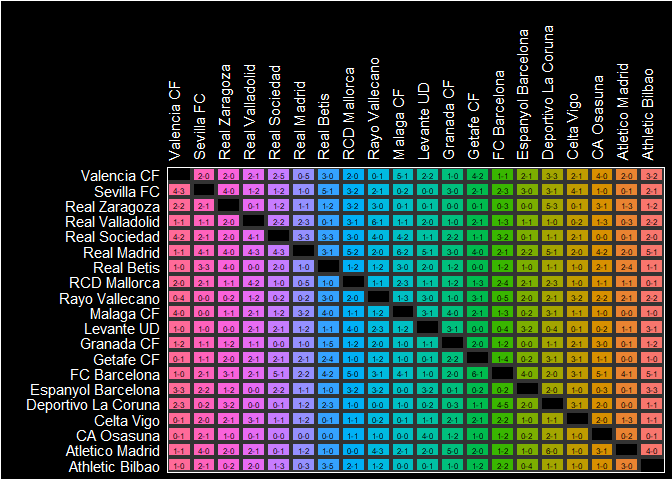

10. تیم های بارسلونا و رئال مادرید، محبوب ترین تیم های لیگ اسپانیا محسوب میشوند. در نمودار های زیر تغییر رتبه این دو تیم طی سال های مختلف را مشاهده میکنید.

[interactive chart not shown]

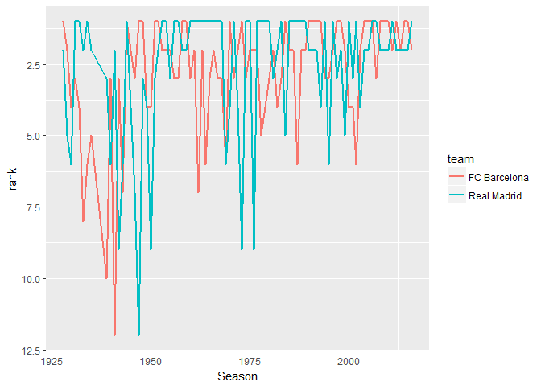

در نمودار زیر سعی شده سنگین ترین شکست در طی این سال ها پیدا شود. محور افقی نمودار نشان دهنده سال و محور عمودی آن، سنگین ترین شکست هر تیم بازی کننده در آن سال را نشان میدهد. با کمال تعجب مشاهده میشود که سنگین ترین شکست با تفاضل 11 گل، مربوط به تیم بارسلونا میباشد.

[interactive chart not shown]

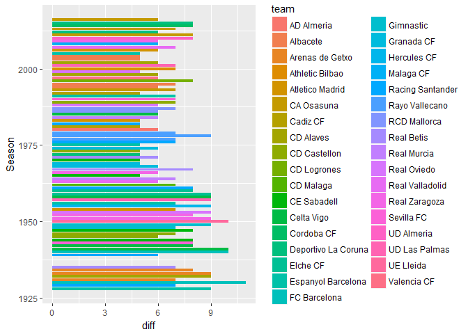

در نمودار زیر برای هر تیم در طی این سالها، درصد بازی هایی که در آن ها میزبان بوده و برده اند مشاهده میشود.  
همچنین حساب شده چند درصد از تیم ها در بیش از 50 درصد برد های خود میزبان بوده اند.

[interactive chart not shown]

```
## [1] 35
```